# Ford GoBike Data Exploration

## by Victoria Bloomingdale

## Investigation Overview

> I chose the Ford GoBike data set provided by the Udacity project page. I was most interested in finding who were the most frequent users, how long did trips last, and what were the bikes primarily used for.

## Dataset Overview

> The data set includes information for the month of February, 2019, about individual rides made in a bike-sharing system covering the greater San Francisco Bay area. The original dataset had 183412 entries and 16 columns. Most of the columns were either numeric or strings. After cleaning, 'start_time' and 'end_time' were converted to datetime type, columns with id's converted to strings, 'user_type' and 'member_gender' to categories, and 'member_birth_year' to int.

## User Types

> The data set included user types and gender. Subscribers far outnumbered casual users. When looking at genders, there were three times as many male users than female users.

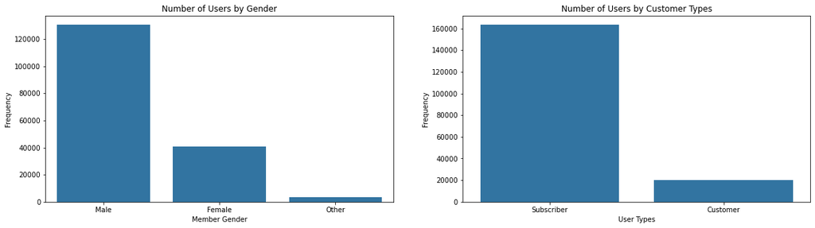

## Trip Duration by Age and Gender

> Although the number of male users was far higher than the other groups, all three gender groups showed similar trip duration broken down by age. Longer trips were usually taken by those between 20- to 45-year-olds regardless of gender.

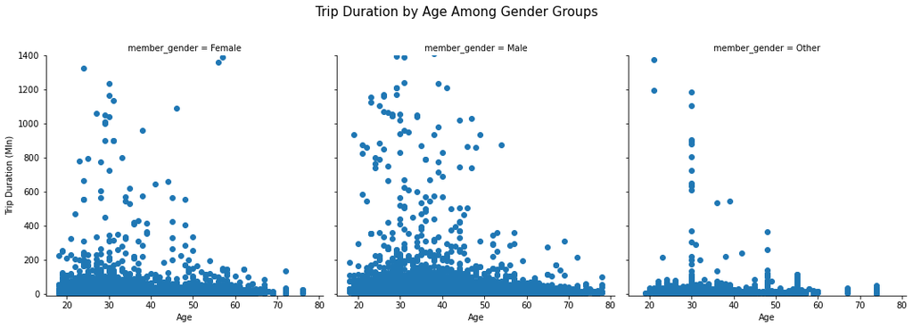

## Average Trip Duration by User Type

> Higher number in user type did not mean longer trips either. The average trip duration was greater for customers than subsribers.

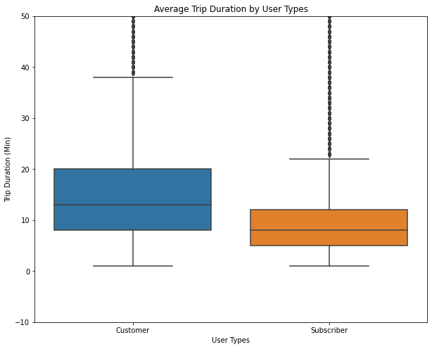

## Bike to Work

> When looking at what time and which days the bikes were used most frequently, the hours and days coincided with regular commute hours. This is a good indication that the bikes were used to quickly travel to and from work.

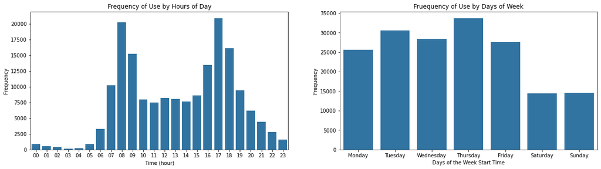

## Enjoy the Weekend

> When broken down by days of the week, male users and subscribers consistently took shorter trips than the other groups. However, all user groups took longer trips on the weekends than weekdays.

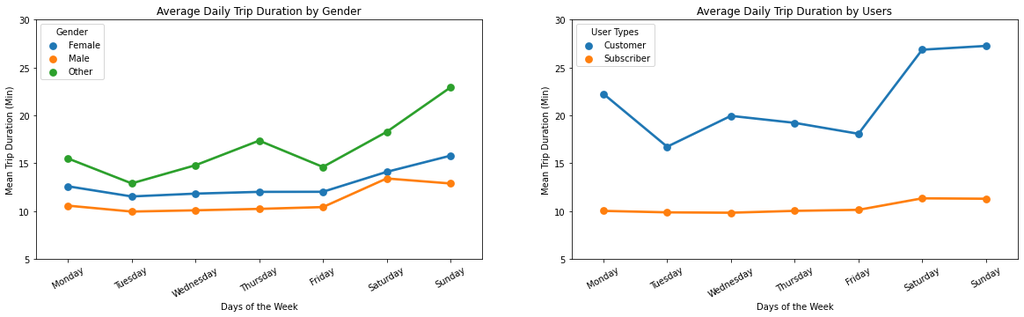

## Conclusion

> It was interesting to see that higher user numbers did not translate to longer trips since the data seemed to indicate the bikes were used mostly for work commute. Once the work week was over, users tended to take longer trips.